# Introductory RMarkdown

Xiaojun Sun  
July 23th, 2014

### What's R?

R is a language and environment for statistical computing and graphics.

[R Homepage](http://www.r-project.org/)

[R Language Features](http://www.revolutionanalytics.com/r-language-features)

[90 second video for an introduction to R](https://www.youtube.com/watch?v=TR2bHSJ_eck)

### What's Markdown?

- Markdown, who R you?
- Markdown is a text-to-HTML conversion tool for web writers. Markdown allows you to write using an easy-to-read, easy-to-write plain text format, then convert it to structurally valid XHTML (or HTML).
- Thus, Markdown is two things:
1. a plain text formatting syntax;
2. a software tool, written in Perl, that converts the plain text formatting to HTML.

### What's Markdown?(cont'd)

- Markdown's syntax is intended for one purpose: to be used as a format for writing for the web.
- Markdown is not a replacement for HTML, or even close to it. Its syntax is very small.
- For any markup that is not covered by Markdown's syntax, you simply use HTML itself.

### What's Markdown?(cont'd)

For example, to add an HTML table to a Markdown article:

```
This is a regular paragraph.

<table>
    <tr>
        <td>Foo</td>
    </tr>
</table>

This is another regular paragraph.
```

### Markdown: Syntax

[Markdown Syntax (English Version)](http://daringfireball.net/projects/markdown/syntax)

[Markdown Syntax (Chinese Version)](http://wowubuntu.com/markdown/)

Block Elements

- Paragraphs and Line Breaks
- Headers
- Blockquotes
- Lists
- Code Blocks
- Horizontal Rules)

### Markdown: Syntax (cont'd)

Span Elements

- Links
- Emphasis
- Code
- Images

Miscellaneous

- Backslash Escapes
- Automatic Links

### Markdown: Paragraphs and Line Breaks

A paragraph is simply one or more consecutive lines of text, separated by one or more blank lines. Markdown supports “hard-wrapped” text paragraphs.

When you want to insert a `<br />` break tag using Markdown, you end a line with two or more spaces, then type return.

### Markdown: Headers

Setext-style headers are “underlined” using equal signs and dashes. For example:

```
This is an H1
=============
This is an H2
-------------
```

Atx-style headers use 1-6 hash characters at the start of the line, corresponding to header levels 1-6. For example:

```
# This is an H1
## This is an H2
###### This is an H6
```

### Markdown: Blockquotes

Markdown uses email-style `>` characters for blockquoting.

```
> This is the first level of quoting.
>
> > This is nested blockquote.
>
> Back to the first level.
```

It looks like

> This is the first level of quoting.

> > This is nested blockquote.

> Back to the first level.

### Markdown: Lists

Markdown supports ordered (numbered) and unordered (bulleted) lists. Unordered lists use `*`, `+`, and `-` followed by at least one space – interchangably – as list markers. Such as

```
- Red
- Green
- Blue
```

It looks like

- Red
- Green
- Blue

### Markdown: Lists (cont'd)

Ordered lists use numbers followed by periods:

```
1. Bird
3. McHale
2. Parish
```

It looks like

1. Bird
2. McHale
3. Parish

The number doesn't matter.

### Markdown: Code Blocks

To produce a code block in Markdown, simply indent every line of the block by at least 4 spaces or 1 tab. For example:

```
Here is an example of AppleScript:

    tell application "Foo"
        beep
    end tell
```

One level of indentation – 4 spaces or 1 tab – is removed.

Here is an example of AppleScript:

```
tell application "Foo"
    beep
end tell
```

### Markdown: Links

Markdown supports two style of links: *inline* and *reference*. To create an inline link, use a set of regular parentheses immediately after the link text's closing square bracket. For example:

```
This is [an example](http://example.com/ "Title") inline link.

[This link](http://example.net/) has no title attribute.
```

And

```
[WISE](http://www.wise.xmu.edu.cn/index.asp)
```

will creates link to [WISE](http://www.wise.xmu.edu.cn/index.asp)

### Markdown: Links (cont'd)

Reference-style links use a second set of square brackets, inside which you place a label of your choosing to identify the link:

```
This is [an example][id] reference-style link.
```

Then, anywhere in the document, you define your link label like this, on a line by itself:

```
[id]: http://example.com/  "Optional Title Here"
```

### Markdown: Links (cont'd)

Here's an example of reference links in action:

```
I get 10 times more traffic from [Google] [1] than from
[Yahoo] [2] or [MSN] [3].

[1]: http://google.com/        "Google"
[2]: http://search.yahoo.com/  "Yahoo Search"
[3]: http://search.msn.com/    "MSN Search"
```

### Markdown: Links (cont'd)

Using the implicit link name shortcut, you could instead write:

```
I get 10 times more traffic from [Google][] than from
[Yahoo][] or [MSN][].

[google]: http://google.com/        "Google"
[yahoo]:  http://search.yahoo.com/  "Yahoo Search"
[msn]:    http://search.msn.com/    "MSN Search"
```

Both give you:

I get 10 times more traffic from [Google](http://google.com/) than from [Yahoo](http://search.yahoo.com/) or [MSN](http://search.msn.com/).

### Markdown: Emphasis

Markdown treats asterisks (`*`) and underscores (`_`) as indicators of emphasis. E.g., this input:

```
*single asterisks*

_single underscores_

**double asterisks**

__double underscores__
```

### Markdown: Emphasis (cont'd)

They will produce:

*single asterisks*

*single underscores*

**double asterisks**

**double underscores**

### Markdown: Code

To indicate a span of code, wrap it with backtick quotes (`` ` ``). Unlike a pre-formatted code block, a code span indicates code within a normal paragraph. For example:

```
Use the `read.table()` function.
```

will produce:

Use the `read.table()` function.

To include a literal backtick character within a code span,

```
``There is a literal backtick (`) here.``
```

`` There is a literal backtick (`) here. ``

### Markdown: Images

Markdown uses an image syntax that is intended to resemble the syntax for links, allowing for two styles: *inline* and *reference*.

Inline image syntax looks like this:

```
![Alt text](/path/to/img.jpg)

![Alt text](/path/to/img.jpg "Optional title")
```

### Markdown: Images (cont'd)

Reference-style image syntax looks like this:

```
![Alt text][id]
```

Where “id” is the name of a defined image reference. Image references are defined using syntax identical to link references:

```
[id]: url/to/image  "Optional title attribute"
```

### Markdown: Images (cont'd)

For example,

```
![XMU, Lotus Lake](http://i.imgbox.com/NN29CSyH.jpg "XMU, Lotus Lake")
```

It will insert photo here:

[figure not shown]

### Markdown: Automatic Links

Markdown supports a shortcut style for creating “automatic” links for URLs and email addresses: simply surround the URL or email address with angle brackets.

You can do this:

Markdown will turn this: http://www.xmu.edu.cn/

### Markdown: Backslash Escapes

Markdown allows you to use backslash escapes to generate literal characters which would otherwise have special meaning in Markdown's formatting syntax.

If you wanted to surround a word with literal asterisks, you can use backslashes before the asterisks, like this:

```
\*literal asterisks\*
```

It gives you:

*literal asterisks*

### RMarkdown: Introduction

> R Markdown is an authoring format that enables easy creation of dynamic documents, presentations, and reports from R. It combines the core syntax of markdown with embedded R code chunks that are run so their output can be included in the final document. R Markdown documents are fully reproducible (they can be automatically regenerated whenever underlying R code or data changes).

This is what I want to show you!

### RMarkdown: Syntax

- Markdown Basics
- R Code Chunks
- Inline R Code
- Embedding Equations
- Output Options
- Shiny
- knitr package

### RMarkdown: R Code Chunks

```r
summary(cars)
```

```
     speed           dist
 Min.   : 4.0   Min.   :  2
 1st Qu.:12.0   1st Qu.: 26
 Median :15.0   Median : 36
 Mean   :15.4   Mean   : 43
 3rd Qu.:19.0   3rd Qu.: 56
 Max.   :25.0   Max.   :120
```

### RMarkdown: R Code Chunks (cont'd)

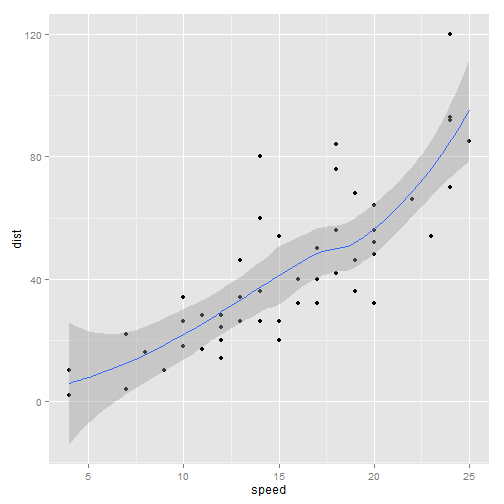

```r
library(ggplot2)
qplot(speed, dist, data=cars)+geom_smooth()
```

### RMarkdown: Inline R Code

You can also evaluate R expressions inline by enclosing the expression within a single back-tick qualified with `r`. For example,

```r
x=2
y=45
```

Then the following code:

```
I get ` r x` jobs and each pays me ` r y` a day. Then I earn $ ` r x*y` a day.
```

(remove the space before `r`) gives you:

I get 2 jobs and each pays me $ 45 a day. Then I earn $ 90 a day.

### RMarkdown: Embedding Equations

You can embed LaTeX or MathML equations in R Markdown files using the following syntax:

- `$equation$` for inline equations (note there must not be white space adjacent to the $ delimiters)
- `$$ equation $$` for display equations
- `<math ...> </math>` for MathML equations.

### RMarkdown: Embedding Equations (cont'd)

```
The combined forecast is:
$$Y_{t,1}^{c}=kY_{t,1}^{1}+(1-k)Y_{t,1}^{2}$$
```

It gives you:

The combined forecast is: \[ Y_{t,1}^{c}=kY_{t,1}^{1}+(1-k)Y_{t,1}^{2} \]

```
The Arithmetic mean is equal to $\frac{1}{n} \sum_{i=1}^{n} x_{i}$.
```

will give you:

The Arithmetic mean is equal to \( \frac{1}{n} \sum_{i=1}^{n} x_{i} \).

### RMarkdown: Output Options

R Markdown documents can contain a metadata section that includes both title, author, and date information as well as options for customizing output.

```
---
title: "Sample Document"
output:
  html_document:
    toc: true
    theme: united
  pdf_document:
    toc: true
    highlight: zenburn
---
```

### RMarkdown: Shiny

[figure not shown]

### RMarkdown: knitr package

Elegant, flexible and fast dynamic report generation with R

The knitr package was designed to be a transparent engine for dynamic report generation with R.

[knitr package options](http://yihui.name/knitr/options)

You needn't know all of them.

### RMarkdown: Editor

[StackEdit](https://stackedit.io/)

[Sublime Text 2](http://www.sublimetext.com/)

RStudio

[maxiang](http://maxiang.info/)

### RMarkdown: example

[figure not shown]

### Thank you!

We R together.

[figure not shown]